# Consumption for automatic and manual transmission

Jacques wagstaff

21 December 2016

## Executive Summary

Looking at a data set of a collection of cars, we are interested in exploring the relationship between a set of variables and miles per gallon (mpg). We are interested in the following two questions:

- “Is an automatic or manual transmission better for MPG”
- “Quantify the MPG difference between automatic and manual transmissions”

We have fitted a model, including all important regressors, and concluded that there is no significant change in mpg from automatic to manual given the data.

## Exploratory Data Analysis

First we collect data, and make factor variables

```r
data<-mtcars
data$cyl  <- factor(data$cyl); data$vs   <- factor(data$vs); data$gear <- factor(data$gear)
data$carb <- factor(data$carb); data$am   <- factor(data$am,labels=c("Automatic","Manual"))
```

Then we make an exploratory plot

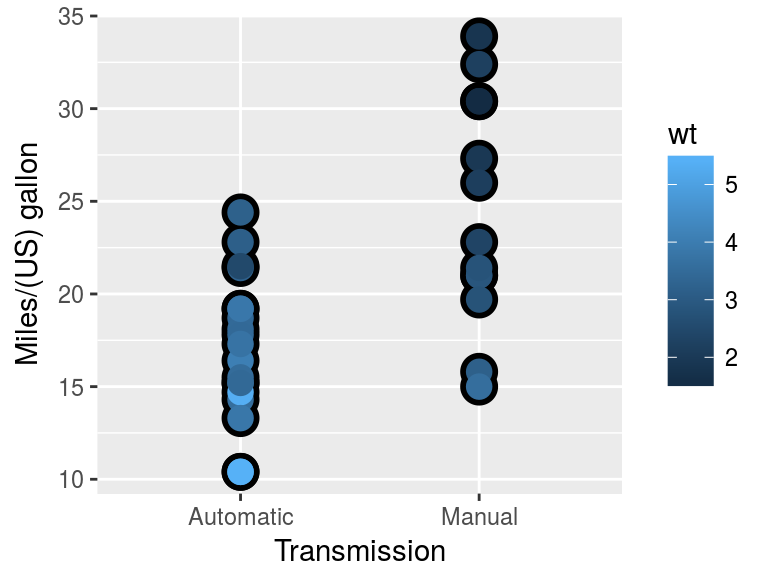

It looks like there is a difference in the avg mpg between automatic and manual transmission, however there are a number of cofounding variables. In this plot we see how weight can have such an effect.

## Fitting multiple models and model selection strategy

The first model is to fit all the variables as regressors. Then we want to find the best model by testing which regressors are important or not. The ‘step’ function fits many models and finds the best.

```r
fitAll<-lm(mpg~.,data = data)
fitBest <- step(fitAll, direction = "both",trace = 0)
```

Here we show a summary of the best model, and plot the diagnostics

```r
round(summary(fitBest)$coeff,3)
```

```
##             Estimate Std. Error t value Pr(>|t|)
## (Intercept)   33.708      2.605  12.940    0.000
## cyl6          -3.031      1.407  -2.154    0.041
## cyl8          -2.164      2.284  -0.947    0.352
## hp            -0.032      0.014  -2.345    0.027
## wt            -2.497      0.886  -2.819    0.009
## amManual       1.809      1.396   1.296    0.206
```

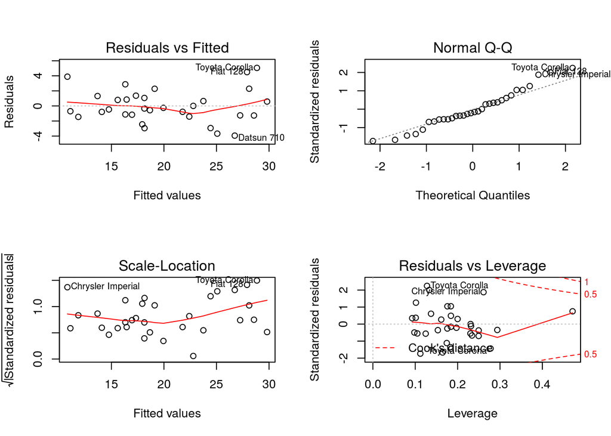

We see no clear patterns in the residual plots, hence the model fits the data well. We also see from the Q-Q plot that the errors are Gaussian as assumed.

## Conclusion

Now we can answer the questions:

- “Is an automatic or manual transmission better for MPG”
- “Quantify the MPG difference between automatic and manual transmissions”

By looking at the coefficient for manual transmission, we see that changing from automatic to manual increases the mpg on average by 1.8, keeping all other variables constant. However, looking at the p-value for this coefficient, we see that this result is not significant, i.e. the confidence interval includes zero. There is no significant change in mpg from automatic to manual given the data.